# Padrões de crescimento de árvores em floresta Amazônica

Eric Bastos Gorgens, UFVJM

02 Nov 2022 13:51:16 -03

Abstract

# 1 Introdução

A exploração madeireira legal é executada através do plano de manejo florestal sustentável, no qual é baseado em instrumentos reguladores para embasar a intensidade da atividade de retirada da madeira, sendo diretamente relacionada com o estoque de crescimento (OLIVEIRA L.C.L.Q., G. J. M., Silva J.F.C., ).

O incremento das árvores, ou crescimento, é consequente das atividades meristemáticas que fornecem alterações nas suas características diamétricas, altimétricas e volumétricas das árvores. No qual, os fatores tanto genéticos quanto ambientais influenciem na forma e tamanho dessas dimensões (CANHOTO J.M., ; SETTE JR C.R., ).

Em geral, os parâmetros de avaliação do crescimento diamétrico das espécies ocorrem de modo generalista, onde as tomadas de decisões no manejo florestal influenciam no desaparecimento ou taxas de crescimento não significativas de espécies importantes para fins ambientais e econômicos (CONDÉ T.M., ).

No intuito de se compreender melhor a dinâmica de crescimento das florestas nativas da Amazônia, diminuindo o efeito da complexidade de sua biodiversidade, efetua-se o agrupamento por grupos conforme suas estratégias de vida e requisitos de iluminação (CAMPANELLO P.I., ; CLARK D.A., ; DENSLOW J.S., ; S., [*s. d.*]; SWAINE M.D., ; WITHMORE T.C., ).

Avaliar o crescimento diamétrico em função das especificidades de cada grupo ecológico, apresenta perspectivas de fornecimento de subsídios para novos níveis de critérios de cortes, diâmetros mínimos de corte e intensidade de exploração que favorecem um manejo florestal que promova menos distúrbios e melhores recuperações das florestas ao seu estado natural (ANDRADE C.G.C., ; SIVIERO M.A., ).

Assumindo-se que esses diferentes grupos ecológicos apresentam distintos papéis nas comunidades florestais, em razão das suas estruturas populacionais. Tem-se a hipótese que apresentam diferentes taxas de crescimentos diamétricos. Com isso, o objetivo do presente trabalho foi avaliar o incremento diamétrico e distribuição diamétrica de árvores de floresta nativas da Amazônia brasileira.

# 2 Material e métodos

Este estudo incluiu 28 inventários contínuos distribuidos nos estados do Pará, Amazonas, Acre, Rondônia e Mato Grosso. No total, foram analisadas 355 parcelas contendo 41580 indíviduos. Os dados fazem parte do projeto Paisagens Sustentáveis Brasil e estão disponíveis para download na plataforma do projeto (https://www.embrapa.br/en/busca-de-solucoes-tecnologicas/-/produto-servico/3862/paisagens-sustentaveis). Após descartadar todas as árvores com diâmetros menores que 10 cm, e também as palmeiras, restaram 36283 árvores.

O incremento diamétrico anual ($d_{growth}$) foi determinado pela da divisão do incremento diamétrico observado entre o diâmetro da primeira e da segunda medição, pelo período em anos entre as medições.

$$d_{growth} = \frac{d_f - d_i}{t_f - t_i}$$
$d_{growth}$ é o incremento diamétrico anual, $d_f$ é o diâmetro a 1,30m obtido no último ano de medição, $d_i$ é o diâmetro a 1,30 m obtido no primeiro ano de medição, $t_f$ é a data da última medição e $t_i$ é a data da primeira medição.

O incremento diamétrico relativo ($d_{rGrowth}$) pôde ser calculado dividindo o incremento diamétrico anual pelo diâmetro a 1,30 obtido na primeira medição:

$$d_{rGrowth} = \frac{d_{growth}}{d_i}$$

Em que $d_{rGrowth}$ é o incremento diamétrico relativo, $d_{growth}$ é o incremento diamétrico anual e $d_i$ é o diâmetro a 1,30 m obtido na primeira medição.

As espécies foram agrupadas com base nos grupos ecológicos propostos por MACPHERSON A.J. As espécies cujo grupo ecológico foram indeterminar, foram excluídas da comparação. Os grupos foram comparados quanto ao incremento diamétrico relativo e quanto à distribuição diamétrica. A comparação entre grupos foi feita utilizando a estatística bayesiana implementada no pacote *rstanarm* e *bayesplot*, ambos para linguagem R de programação.

O modelo linear generalizado da função gama, com ligação logarítmica, foi usado para comparar o efeito dos grupos ecológicos no incremento relativo. Para analisar o efeito dos grupos eológicos na distribuição diamétrica, foi utilizado o modelo de Meyer linearizado, com a função de ligação identidade. The statistical analysis performed a Bayesian estimation via MCMC of the generalized linear models. The Bayesian model adds priors on the coefficients of the GLM, and compute the posterior values based on observed data (MUTH; ORAVECZ; GABRY, 2018).

O modelo de Meyer é definido como:

$$N_j = e^{\beta_0 + \beta_1 D_j}$$

em que $N_j$ indica o número de indivíduos na classe de diâmetro $j$ e $D_j$ indica o centro da classe $j$. E pode ser generalizado por meio da transformação logaritmica da variáveis dependente:

$$log(N_j) = \beta_0 + \beta_1 D_j$$

# 3 Resultados

Das 415 espécies inventariadas, 90 foram associadas a um dos 5 grupos ecológicos: 13 espécies foram assinaladas como pioneiras, 13 como demadantes de luz, 34 como intermediárias, 20 como tolerantes à sombra e 10 como emergentes. O grupo ecológico das demandantes de luz apresentou o maior incremento diamétrico relativo esperado e também a maior variação: mediana de 1.7% ao ano, com distância interquartil de 3.0%. Em ordem decrescente, observou-se o grupo das pioneiras (0.9%, IQR: 1.6%), das intermediárias (0.7%, IQR: 1.3%), das emergentes (0.6%, IQR: 1.8%) e das tolerantes à sombra (0.6%, IQR: 1.0%) (Table 3.1).

Table 3.1: Resumo dos grupos ecológicos.

| GrupoEco | arvProp | incDesv | rInc |
| --- | --- | --- | --- |
| Emergent | 3.19852 | 0.0185160 | 0.0065034 |
| Intermediate | 30.97064 | 0.0131193 | 0.0070225 |
| Light-demanding | 18.81287 | 0.0298942 | 0.0169335 |
| Pioneer | 17.37412 | 0.0162653 | 0.0090160 |
| Shade-tolerant | 29.64385 | 0.0101931 | 0.0059524 |

O grupo das emergentes é o menor grupo, contendo 3.1% das árvores. O grupo mais numeroso é o grupo das intermediárias (31%) seguindo pelo grupo das tolerantes a sombra (29%). Os grupos das pioneiras e das demantantes de luz representam as demais espécies, numa porporção de 17% e 19% respectivamente (Table 3.1).

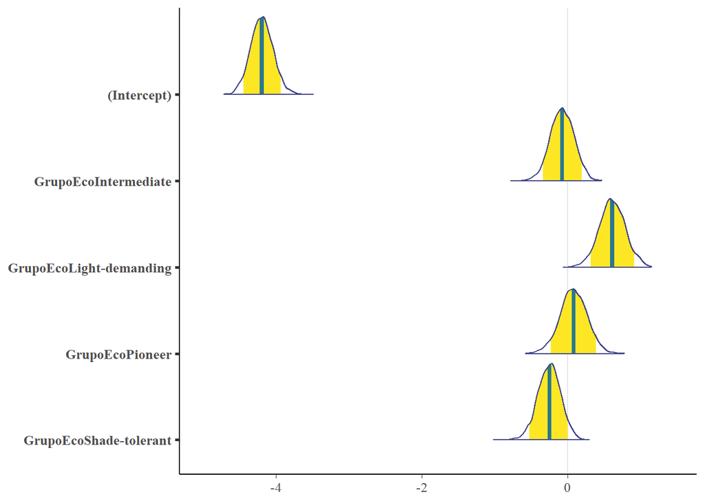

Figure 3.1: Análise bayesiana comparando o incremento relativo entre grupos ecológicos.

Como resultado da análise bayesiana, em relação à taxa de crescimento diamétrico relativo, os grupos ecológicos podem ser separados em três agrupamentos: um contendo os grupos das emergentes, das pioneiras e das intermediária; outro contendo apenas as demandantes de luz e outro contendo apenas as tolerantes a sombra.

A distribuição diamétrica de todos os grupos ecológicos apresentaram forte assimetria a esquerda, com um comportamento exponencial negativo, também conhecido como “J-invertido”, mas com taxas de descréscimo diferentes (Figure 3.2). O grupo das emergentes apesar de também apresentar uma forma expoencial, o decréscimo entre classes foi inferior se comparados aos demais grupos (diferenças menores entre os números de árvores das classes diamétricas).

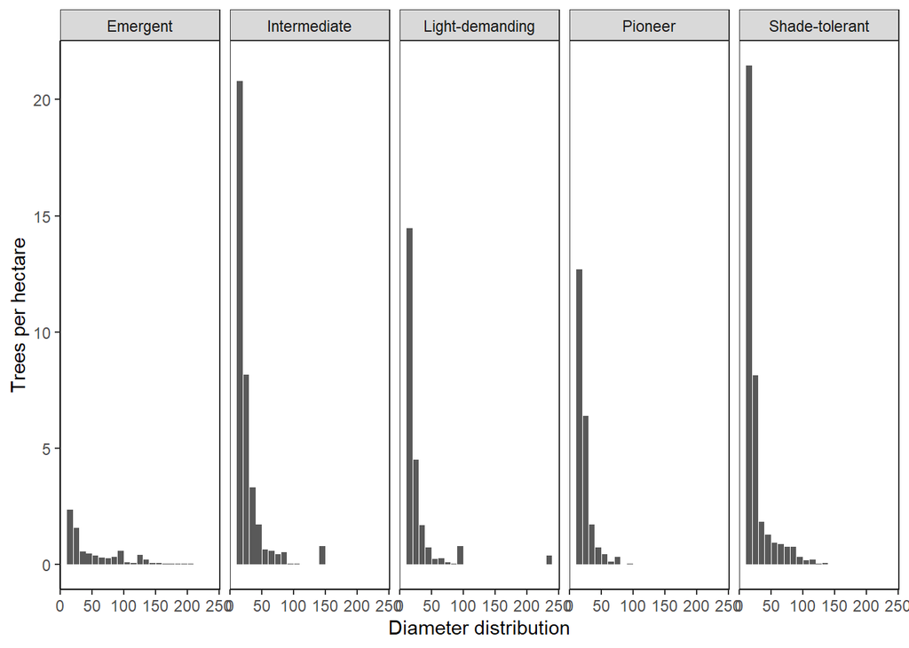

Figure 3.2: Distribuição diamétrica para cada grupo ecológico.

O coeficiente angular do modelo de Meyer linearizado evidencia o grupo ecológico das emergentes com a menor taxa de decréscimo (Figure 3.3). Já o grupo das pioneiras possui a maior taxa de decréscimo. Os grupos das intermediárias, das tolerantes a sombra e das demantantes de luz ocupam postos entre os grupos já mencionados, em posições crescentes. O interceto do modelo, indica o grupo das emergentes apresentando o menor número de árvores na classe inicial dentre os grupos. Seguido pelas demandantes de luz, e por um grupo formado pelas intermediárias, pioneiras e tolerantes à sombra, com a maior quantidade de indivíduos na classe diamétrica inicial.

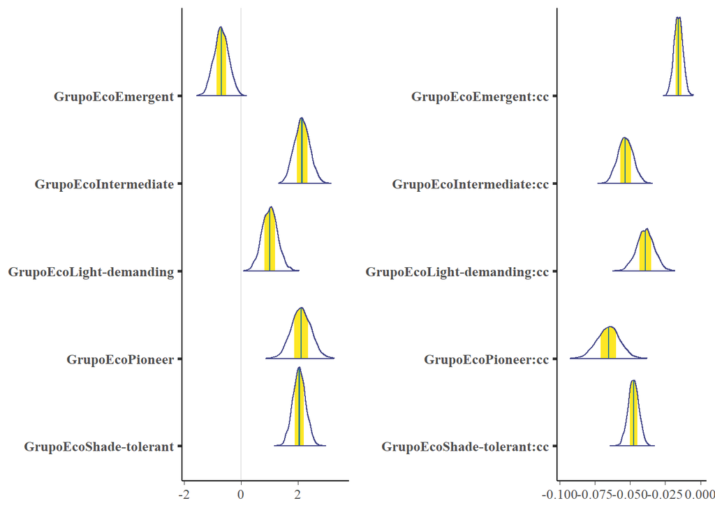

Figure 3.3: Análise bayesiana comparando a taxa de descréscimo exponencial para o número de árvores por classe diamétrica entre grupos ecológicos.

# 4 Discussão

Embora exista variados tipos de agrupamento de espécies de acordo com sua ecofisiologia, como apresentado por BUDOWKI G., KUCHLER A.W., SWAINE M.D., S. ([*s. d.*]) e MACPHERSON A.J que foi adotado nesse estudo, influencia em uma maior diversidade de comparativos e também da impossibilidade de agrupamento de algumas espécies nesses grupos.

Como apresentado por NARDUCCI T.S. (2020) em seu estudo identificou 104 espécies, no qual apenas 61 espécies, ou seja, 58,7% foram classificadas em grupos ecológicos, onde 35 pertenciam ao grupo das pioneiras, 13 da secundárias inicias e 23 nas secundárias tardias. Em comparativo a frequência apresentada nesse estudo, as secundárias inicias se assemelham as características das demandantes de luz e as secundárias tardias como intermediárias e tolerantes à sombra.

Assim como nesse estudo, OLIVEIRA L.C.L.Q., G. J., Jardim F. verificou que o grupo das tolerantes à sombra e intermediárias foram o com maior expressividade de frequência de indivíduos por espécie, com cerca de 45,55% respectivamente.

A menor quantidade de indivíduos de espécies inseridas no grupo das pioneiras, em contrapartida aos maiores valores de número de espécies nas tolerantes à sombra e intermediária, é um indicativo que essas comunidades florestais podem apresentar um maior grau de maturidade, como demonstrado por LAU A.V.

Em geral, o incremento diamétrico (G) é avaliado a partir da diferença entre o diâmetro final e o diâmetro inicial em determinado tempo (AMARAL M.R., ; VATRAZ S., ). E o incremento diamétrico anual (Growth) é a divisão do G pelos períodos entre as duas medições (PEREIRA R.S., 2020). Porém, esse cálculo apresenta influência da forma da árvore. Em alternativa a essa problemática se tem a implementação do incremento diamétrico relativo.

Avaliando-se em função dos grupos ecológicos, verificou-se que as tolerantes à sombra, que são espécies que geralmente apresentam maiores densidades, obtiveram taxas de crescimento relativo mais baixos que os demais grupos, refletindo em um crescimento mais lento (WORBES M., ).

VATRAZ S. também verificou em seu estudo que as tolerantes à sombra apresentam taxas de incremento diamétrico menores que comparado aos demais grupos ecológicos. Possivelmente sendo uma resposta fisiológica do seu custo de investimento de construção de tecidos para sustentação de suas copas e proteção a danos físicos, o que favorece indivíduos com ciclo de vida maiores em contrapartida aos exigentes de luminosidade (KING D.A., ; POORTE L., )

S. ([*s. d.*]) diz que as espécies com características das demandantes de luz apresentam rápido crescimento vegetativo, justificando suas maiores taxas de incremento diamétrico relativo. Essas árvores apresentam uma alta resposta reprodutiva em função da luz, crescendo em locais abertos, semiabertos e em clareiras na floresta (LUAMBUA N.K., ), além de baixas densidades de madeira e uma alta eficiência em transportar água (CAMPANELLO P.I., ).

Em colaboração aos resultados desse estudo, LOREGIAN A.C. verificou ao analisar os padrões ecológicos e espaciais de espécies de florestas naturais que o maior grupo de indivíduos amostradas estudados foram espécies caracterizadas como demandantes de luz, em que relacionou essa frequência como uma resposta de condições de desenvolvimento e estabelecimento inicial de espécies.

De modo geral, SCHÖNGART J. enfatiza que o favorecimento de crescimento mais rápidos de espécies da Amazônia é bastante influenciado pelas áreas com maiores riqueza em nutrientes, embora os solos de terra firme que caracterizam a maior parte das áreas das bases estudadas sejam caracterizados por serem ácidos e mais pobres em nutrientes (NETA E.D.F.B., ).

GOUVEIA D. ao avaliar o crescimento de espécies por grupo ecológico em áreas na FLONA do Tapajós, verificou que a média do incremento diamétrico através do método convencional das pioneiras foi de 0,70, as secundárias inicias com 0,69, secundárias tardias 0,39 e clímax (0,29).

AMARAL M.R. a partir do estudo da dinâmica de floresta da Amazônia Central após 25 anos de corte experimental, notou que o crescimento médio de diâmetro de espécies foi de 0,25 a 0,30 cm/ano.

PEREIRA R.S. (2020) ao apresentar os resultados do incremento diamétrico anual médio nos grupos ecológicos verificou que o grupo das tolerantes à sombra com 0,49 cm/ano foi o que apresentou menores valores em contrapartida aos demais.

Com relação as distribuições dos incrementos relativos obtidos através do modelo bayesiano generalizado, os resultados gerados demonstraram uma provável diferença entre as distribuições incremento diamétrico relativo das demandantes de luz em relação aos demais grupos.

É possível que as taxas de crescimento mais elevadas para esse grupo justifiquem sua distribuição diferenciada, enquanto, que os valores dos outros grupos foram ligeiramente menores apresentaram possível semelhanças nas distribuições.

Como consequência disso, não é possível inferir que as espécies sejam manejadas de modo igual, mas sim acentuar a necessidade de um olhar mais específico do manejador em perceber que em determinados locais esses grupos ecológicos apresentarão taxas de crescimento menores.

Se há diferença em um dos grupos, é possível que as inferências empregadas nos parâmetros das tomadas de decisões do manejo florestal devam ser reavaliadas, de forma a incentivar o conhecimento sobre o crescimento das árvores, para entendimento da dinâmica das florestas tropicais, além do seu desenvolvimento em relação as interferências sofridas no ecossistema em função do tempo (MARTINS J.P., 2019; VELOSO L.C., ).

A tendência de distribuição de diâmetros que a maior parte dos grupos apresentaram, demonstra que as populações que compõem esses grupos ecológicos apresentam um melhor balanço entre a mortalidade e o ingresso de indivíduos. Todavia, nem todas as todas distribuições diamétricas de florestas nativas seguirão de modo obrigatório o formato de exponencial negativo, ou, será balanceada.

Pois, algumas espécies precisam de um maior tempo e espaço para uma maior taxa de regeneração (FELFILI, 1997). Com isso, apresentam uma distribuição que não segue a estrutura de “J-invertido” e diferentes valores de incremento (BETTINGER *et al.*, 2009; BRAZ E.M., 2010; CANETTI A., 2019; DAWKINS, H., 1998).

Tendo em vista da importância que a regeneração é extremamente importante para a produção sustentável e recomposição de madeiras, é necessário maiores entendimentos sobre essas espécies que não possuem número expressivos de regenerantes, para possíveis intervenções silviculturais (DICKINSON M.B., ; ERDMANN A.A., 2019; PUTZ F.E., )

As avaliações das distribuições diamétricas são relevantes tanto do ponto de vista silvicultural, por sugerir melhores critérios de exploração, quanto do ponto de vista ecológico por fornecer melhores caracterizações dos traços dos determinados grupos de espécie (INGA J.G., ).

Do ponto de vista ecológico, CARVALHO F.A. apontaram que o fato das espécies que podem ser classificados como demandantes de luz, intermediárias e tolerantes à sombra apresentarem essa concentração de indivíduos nas classes inicias de diamétrico, indica um provável avanço de estágios sucessionais maduros, em razão da elevada regeneração.

OLIVEIRA L.C.L.Q., G. J., Jardim F. em seu estudo sobre prognose da distribuição diamétrica de espécies arbóreas classificadas em grupos ecológicos em uma floresta tropical de terra firme, também apresentou que os indivíduos tolerantes à sombra e intermediárias apresentam de modo evidente a distribuição diamétrica como “J-invertido”.

SANTOS R.O. verificou também que as espécies com característica das demandantes de luz, intermediárias e tolerantes à sombra apresentaram comportamento de exponencial negativo.

A partir do modelo bayesiano generalizado da distribuição diamétrica em função dos grupos ecológicos, observou-se que os grupo das intermediárias e tolerantes à sombra apresentam prováveis semelhanças nas distribuições. Enquanto que o grupo das pioneiras, demandantes de luz e emergentes apresentam prováveis diferenças nas distribuições diamétricas.

A avaliação da distribuição diamétrica é uma ferramenta eficaz para descrição das propriedades florestais CANETTI A. (2019), já que o diâmetro é uma variável que pode ser obtida por métodos não destrutivos e está fortemente correlacionada com a variável de importância comercial que é o volume, sendo então um dos critérios empregados para o corte de árvores.

Porém, ao se avaliar que há possíveis diferenças nas distribuições diamétricas das árvores estudadas, é possível que as práticas de manejo estejam retirando indivíduos em classes que não consigam gerar indivíduos suficientes durante os ciclos de corte.

Já que, segundo CYSNEIROS V.C., o grupo ecológico e porte das espécies de florestas tropicais em função do estágio sucessional que predomina a comunidade florestal que estão inseridas, são fatores que podem influenciar diretamente na distribuição diamétrica.

Portanto, os resultados obtidos em função dos grupos ecológicos demonstraram que as avaliações em função de comunidades florestais que fornecem suporte para os parâmetros legais, abrem lacunas para o exercimento de atividades florestais que comprometem a sustentabilidade do manejo.

# References

AMARAL M.R., H. F. G., Lima A.J. Dynamics of tropical forest twenty-five years after experimental logging in Central Amazon mature forest. **Forests**, [*s. l.*], v. 10, n. 2, p. 89, Disponível em: [https://doi.org/10.3390/f10020089.](https://doi.org/10.3390/f10020089)

ANDRADE C.G.C., A. D. F., Ruschel A.R. **Variáveis ecológicas essenciais ao manejo florestal na Amazônia brasileira**. Editora CRV, Disponível em:

BETTINGER *et al.* **Forest management and planning**. [*S. l.*]: Academic Press, 2009. *E-book*. Disponível em:

BRAZ E.M. **Subsídios para o planejamento de manejo de florestas tropicais da Amazônia**., 2010. Disponível em:

BUDOWKI G. Distribution of tropical American rain forest species in the light of successional processes. **Turrialba**, [*s. l.*], v. 15, n. 1, p. 40–42, Disponível em:

CAMPANELLO P.I., A. A., Gatti M.G. Tree regeneration and microclimate in a liana and bamboo-dominated semideciduous Atlantic Forest. **Forest Ecology and Management**, [*s. l.*], v. 252, p. 108–117, Disponível em: [https://doi.org/10.1016/j.foreco.2007.06.032.](https://doi.org/10.1016/j.foreco.2007.06.032)

CANETTI A. **Estrutura, dinâmica e manejo sustentável em ecótono de Floresta Amazônica**., 2019. Disponível em:

CANHOTO J.M. Madeira. **Revista Ciência Elementar**, [*s. l.*], v. 6, n. 4, p. 074, Disponível em: [http://doi.org/10.24927/rce2018.074.](http://doi.org/10.24927/rce2018.074)

CARVALHO F.A., N. M. T. Estrutura diamétrica da comunidade e das principais populações arbóreas de um remanescente de Floresta Atlântica Submontana (Silva Jardim-RJ, Brasil). **Revista Árvore**, [*s. l.*], v. 33, p. 327–337, Disponível em: [https://doi.org/10.1590/S0100-67622009000200014.](https://doi.org/10.1590/S0100-67622009000200014)

CLARK D.A., C. D. B. Life history diversity of canopy and emergent trees in a neotropical rain forest. **Ecol.Monogr.**, [*s. l.*], v. 62, p. 315–344, Disponível em: [https://doi.org/10.2307/2937114.](https://doi.org/10.2307/2937114)

CONDÉ T.M., H. N., Tonini H. Effects of sustainable forest management on tree diversity, timber volumes, and carbon stocks in an ecotone forest in the northern Brazilian Amazon. **Land Use Policy**, [*s. l.*], v. 119, p. 106145, Disponível em: [https://doi.org/10.1016/j.landusepol.2022.106145.](https://doi.org/10.1016/j.landusepol.2022.106145)

CYSNEIROS V.C., J. M. J. O., Amorim A.T. Distribuição diamétrica de espécies da Floresta Ombrófila Densa no Sul do Estado do Rio de Janeiro. **Pesquisa Florestal Brasileira**, [*s. l.*], v. 37, n. 89, p. 1–10, Disponível em: [https://doi.org/10.1093/jof/50.2.85.](https://doi.org/10.1093/jof/50.2.85)

DAWKINS, H., P. M. S. **Tropical moist forest silviculture and management: a history of success and failure**. [*S. l.*]: CAB international, 1998. *E-book*. Disponível em:

DE LIOCOURT F. Manejo de los abetales. **Revista Mexicana de Ciencias Forestales**, [*s. l.*], v. 14, n. 66, p. 15–30, Disponível em:

DENSLOW J.S. Tropical rainforest gaps and tree species diversity. **Ann. Rev. Ecol. Sys**, [*s. l.*], v. 18, p. 431–451, Disponível em: [https://doi.org/10.1146/annurev.es.18.110187.002243.](https://doi.org/10.1146/annurev.es.18.110187.002243)

DICKINSON M.B., H. S. M., Whigham D.F. Tree regeration in feeling and natural treefall disturbances in a semideciduous tropical forest in Mexico. **Forest Ecology and Management**, [*s. l.*], v. 134, p. 137–151, Disponível em: https://doi.org/10.1016/S0378-1127(99)00252-2.

ERDMANN A.A. **[Fatores que influenciam a dinâmica florestal após exploração de madeira na Amazônia brasileira](https://doi.org/10.11606/T.11.2019.tde-02092019-095634)**., 2019. Disponível em:

GOUVEIA D., S. W., Soares M. Avaliação do crescimento de espécies florestais por grupo ecológico em áreas exploradas na FLONA do Tapajós. **Encontro Amaz Agrárias III**, [*s. l.*], p. 1–5, Disponível em:

INGA J.G., D. V. J. I. Log-relative growth: A new dendrochronological approach to study diameter growth in Cedrela odorata and Juglans neotropica, Central Forest, Peru. **Dendrochronologia**, [*s. l.*], v. 44, p. 117–129, Disponível em: [https://doi.org/10.1016/j.dendro.2017.03.009.](https://doi.org/10.1016/j.dendro.2017.03.009)

KING D.A., T. S., Davies S.J. The role of wood density and steam support costs in the growth and mortality of tropical trees. **Journal of Ecology**, [*s. l.*], v. 94, n. 3, p. 670–680, Disponível em: [https://doi.org/10.1111/j.1365-2745.2006.01112.x.](https://doi.org/10.1111/j.1365-2745.2006.01112.x)

KUCHLER A.W., E. H., Mueller-dombois D. Aims and methods of vegetation ecology. **Geogr Rev**, [*s. l.*], v. 66, n. 1, p. 45–66, Disponível em:

LAU A.V., J. M. A., Ferreira G. C. Fitossociologia e aspectos ecológicos da comunidade arbórea do Bosque Rodrigues Alves-Jardim Botânico Amazônia, Belém, Pará, Brasil. **Revista Brasileira de Geografia Física**, [*s. l.*], v. 13, n. 2, p. 510–526, Disponível em:https://doi.org/10.26848/rbgf.v13.2.p510-526.

LOREGIAN A.C., Z. E. M., Silva B.B. Padrões espaciais e ecológicos de espécies arbóreas refletem a estrutura em mosaicos de uma floresta subtropical. **Acta Botanica Brasilica**, [*s. l.*], v. 26, n. 3, p. 593–606, Disponível em: [https://doi.org/10.1590/S0102-33062012000300009.](https://doi.org/10.1590/S0102-33062012000300009)

LUAMBUA N.K., S. K. V., Hubau W. Spatial patterns of light‐demanding tree species in the Yangambi rainforest (Democratic Republic of Congo). **Revista Brasileira de Geografia Física**, [*s. l.*], v. 11, n. 24, p. 18691–18707, Disponível em: [https://doi.org/10.1002/ece3.8443.](https://doi.org/10.1002/ece3.8443)

MACPHERSON A.J. **Following the rules: a bioeconomic policy simulation of a Brazilian forest concession**. Disponível em:

MARTINS J.P. **Variáveis ambientais, dinâmica e biomassa em fragmento da floresta ombrófila mista**., 2019. Disponível em:

MEYER A.H. Structure, Growth, and Drain in Balanced Uneven-Aged Forests. **Journal of Forestry**, [*s. l.*], v. 50, p. 85–92, Disponível em: [https://doi.org/10.1093/jof/50.2.85.](https://doi.org/10.1093/jof/50.2.85)

MUTH, C.; ORAVECZ, Z.; GABRY, J. User-friendly Bayesian regression modeling: A tutorial with rstanarm and shinystan. **Quantitative Methods for Psychology**, [*s. l.*], v. 14, n. 2, p. 99–119, 2018. Disponível em:

NARDUCCI T.S., J. B. S., Yared J.A.G. Regeneração natural do sub-bosque em plantios de Taxi-branco (Tachigali vulgaris LF Gomes da Silva & HC Lima) sob diferentes espaçamentos na Amazônia Brasileira. **Biota Amazônia**, [*s. l.*], v. 10, n. 3, p. 16–21, 2020. Disponível em: [http://dx.doi.org/10.18561/2179-5746/biotaamazonia.v10n3p16-21.](http://dx.doi.org/10.18561/2179-5746/biotaamazonia.v10n3p16-21)

NETA E.D.F.B., N. E. Variações sazonais na ciclagem de nutrientes em uma floresta da Amazônia central. **Brazilian Applied Science Review**, [*s. l.*], v. 2, n. 5, p. 1747–1759, Disponível em: [https://doi.org/10.34115/basr.v2i5.563.](https://doi.org/10.34115/basr.v2i5.563)

OLIVEIRA L.C.L.Q., G. J., Jardim F. Classificação ecológica de espécies arbóreas por meio da análise da distribuição diamétrica. **Espacios**, [*s. l.*], v. 38, n. 42, p. 3, Disponível em:

OLIVEIRA L.C.L.Q., G. J. M., Silva J.F.C. Predição do ciclo de corte de espécies arbóreas comerciais por grupos ecológicos em uma floresta na Amazônia brasileira. **Brazilian Journal of Biometrics**, [*s. l.*], v. 38, n. 1, p. 18–34, Disponível em: [https://doi.org/10.28951/rbb.v38i1.412.](https://doi.org/10.28951/rbb.v38i1.412)

PEREIRA R.S. **Simulação do crescimento de árvores nativas considerando abordagem multiagentes**., 2020. Disponível em:

POORTE L., B. F., Bongers L. Architecture of 53 rainforest tree species: tatis, trade off and funcitional groups. **Ecology**, [*s. l.*], v. 87, n. 3, p. 1289–1301, Disponível em: https://doi.org/10.1890/0012-9658(2003)084[0602:AORFTS]2.0.CO;2.

PUTZ F.E. Treatments in tropical silviculture. **Encyclopedia of Forest Sciences**, [*s. l.*], p. 1039–1044, Disponível em:

S., D. A. D. **Recuperação ambiental da Mata Atlântica**. [*S. l.: s. n.*], [*s. d.*]. *E-book*. Disponível em:

SANTOS R.O., R. B. C., Soares R.N. Estrutura e dinâmica em uma floresta densa de terra firme, Sudeste do Amapá, Brasil. **Nativa**, [*s. l.*], v. 6, p. 802–814, Disponível em: [https://doi.org/10.31413/nativa.v6i0.5755.](https://doi.org/10.31413/nativa.v6i0.5755)

SCHÖNGART J., F. S. F., Gribel R. Age and growth patterns of Brazil nut trees (Bertholletia excelsa Bonpl.) in Amazonia, Brazil. **Biotropica**, [*s. l.*], v. 47, n. 5, p. 550–558, Disponível em: [https://doi.org/10.1111/btp.12243.](https://doi.org/10.1111/btp.12243)

SETTE JR C.R., D. C. T. D. S., Tomazello Filho F.D.S. Crescimento em diâmetro do tronco das árvores de Eucalyptus grandis W. Hill. ex. Maiden e relação com as variáveis climáticas e fertilização mineral. **Revista Árvore**, [*s. l.*], v. 34, n. 6, p. 979–990, Disponível em: [https://doi.org/10.1590/S0100-67622010000600003.](https://doi.org/10.1590/S0100-67622010000600003)

SIVIERO M.A., Y. J. A. G., Ruschel A.R. Manejo de florestas naturais degradadas na Amazônia: estudo de caso sobre critérios de colheita. **Ciência Florestal**, [*s. l.*], v. 30, n. 1, p. 43–59, Disponível em: [https://doi.org/10.5902/1980509825856.](https://doi.org/10.5902/1980509825856)

SWAINE M.D., W. T. C. On the definition of ecological species groups in tropical rain forests. **Vegetatio**, [*s. l.*], v. 75, p. 81–86, Disponível em: [https://doi.org/10.1007/BF00044629.](https://doi.org/10.1007/BF00044629)

VATRAZ S., S. J. N. M., Alder D. A autocorrelação temporal do incremento em diâmetro e as diferenças de crescimento entre grupos de espécies em uma floresta ombrófila densa. **Brazilian Journal of Biometrics**, [*s. l.*], v. 36, n. 1, p. 56–73, Disponível em: [https://doi.org/10.28951/rbb.v36i1.118.](https://doi.org/10.28951/rbb.v36i1.118)

VELOSO L.C., F. L. J. M., Mendes F.D.S. Estudo da dinâmica e estrutura de floresta explorada para produção madeireira no município de Anapu, PA. **Seminário de Iniciação Científica da Embrapa Amazônia Oriental**, [*s. l.*], Disponível em:

WITHMORE T.C. Canopy gaps and the two major groups of forest trees. **Ecology**, [*s. l.*], v. 70, p. 536–538, Disponível em:https://doi.org/10.2307/1940195.

WORBES M., S. J. Measures for sustainable forest management in the tropics – A tree-ring based case study on tree growth and forest dynamics in a Central Amazonian lowland moist forest. **Plos One**, [*s. l.*], v. 14, n. 8, p. e0219770, Disponível em: [https://doi.org/10.1371/journal.pone.0219770.](https://doi.org/10.1371/journal.pone.0219770)